# ExtraaLearn Project

Checking the performance on the test data

```
              precision    recall  f1-score   support

           0       0.93      0.81      0.86       980
           1       0.64      0.84      0.73       400

    accuracy                           0.82      1380
   macro avg       0.78      0.83      0.80      1380
weighted avg       0.84      0.82      0.82      1380
```

[figure not shown]

```python
y_pred_test4 = rf_estimator_tuned.predict(X_test)
metrics_score(y_test, y_pred_test4)
```

**Observations:**

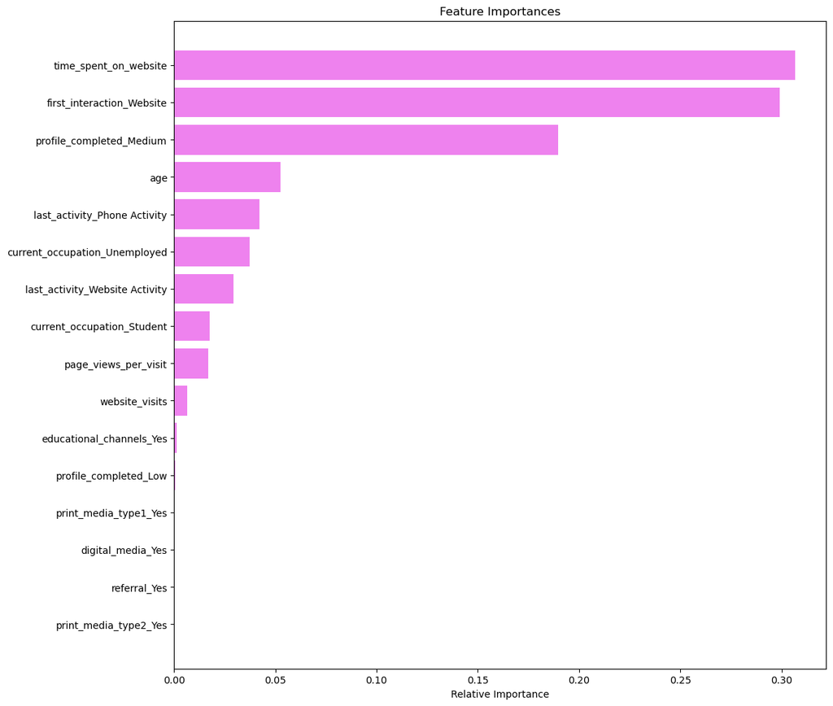

```python
#Lets check the feature importances for this model
importances = rf_estimator_tuned.feature_importances_

indices = np.argsort(importances)

feature_names = list(X.columns)

plt.figure(figsize = (12, 12))

plt.title('Feature Importances')

plt.barh(range(len(indices)), importances[indices], color = 'violet', align = 'center')

plt.yticks(range(len(indices)), [feature_names[i] for i in indices])

plt.xlabel('Relative Importance')

plt.show()
```

**Observations:**

- Similar to the decision tree model, time_spent_on website, first_interaction_website, profile_completed, and age are the top four features that help distinguish between not converted and converted leads.
- Unlike the decision tree, **the random forest gives some importance to other variables like occupation, page_views_per_visit, as well.** This implies that the random forest tuned model is giving importance to more factors and how they impact for future targeting.
- So far, this is the best model giving us good recall scores and better scores than Decision Tree Tuned model.

## Actionable Insights and Recommendations

Based on our model building and predictions, we can classify our recommendations into following strategies.

1. Marketing strategy
2. Advertising Strategy
3. Model Strategy

**Marketing Strategy:**

- According to the statistics, our analysis shows that professional or Employed customers are very much interested in the program The company should customize more strategize to attract more such customers.
- The analysis also shows that Unemployed Leads are interested in the programs offered. So, company should give them discounts and offers for higher conversions.
- Most of the Leads visiting the website are filling up their personal information. The company should expand its marketing strategies to increase the conversion rate by contacting them and giving them offers.
- We saw in our analysis that people who are being referred have high chances of conversion rates.The company should give them offers.
- We also saw the Leads who interacted with Email or Website using Live char have high chances of conversion. The company should be readily available for them and give them offers.
- When implementing a marketing strategy, external factors, such as the number of follow-ups using Email activity, time of call, should also be carefully considered as our analysis shows that the customers who have been followed up more are the ones who hhave potential to become paid customers.
- After we identify a potential customer, the company should pitch more offers based on their needs.

**Model Strategy:**

- Based on our Model training and tuning, Decision Tree Hyperparameter tuning and Random Forest tuned model have given us highest performances.
- The features like time_spent_on website, first_interaction_website, profile_completed, Age are the top four features or factors to be considered for high conversion rate.
- RF tuned Model with entropy criterion also gives feature importance to these features, along with other features which can be used for strategizing and target various customers.